# Simultation Example

## Simulation Exercise Instructions

In this project you will investigate the exponential distribution in R and compare it with the Central Limit Theorem. The exponential distribution can be simulated in R with rexp(n, lambda) where lambda is the rate parameter. The mean of exponential distribution is 1/lambda and the standard deviation is also 1/lambda. Set lambda = 0.2 for all of the simulations. You will investigate the distribution of averages of 40 exponentials. Note that you will need to do a thousand simulations.

1.- Show the sample mean and compare it to the theoretical mean of the distribution.

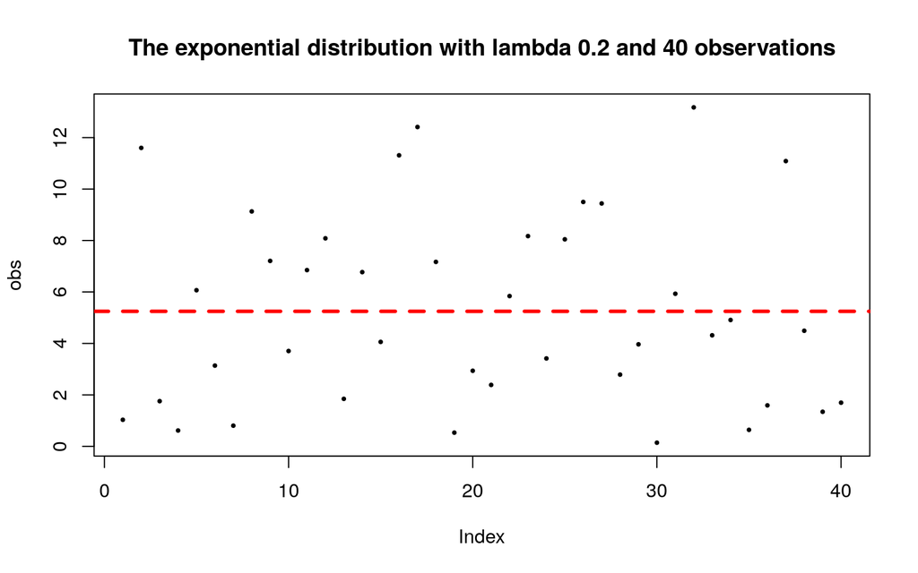

```r
library(ggplot2)
n=40
lambda =.2
mu <- 1/lambda
s <- 1/lambda
sim <- 1000

obs <- rexp(n,lambda)

plot(obs, pch=20, cex=0.6, main=paste0("The exponential distribution with lambda ",lambda," and ",n," observations"))
abline(h=mean(obs), col="red", lwd=3, lty=2)
text(100, 30, paste("Actual mean = ", round(mean(obs),2), "\n Theoretical mean = ",mu ), col="red")
```

```r
# theoretical mean  vs sample mean
print (paste("Population mean: ", mu, ", Sample mean: ", round(mean(obs) ,4) ) )
```

```
## [1] "Population mean:  5 , Sample mean:  5.2475"
```

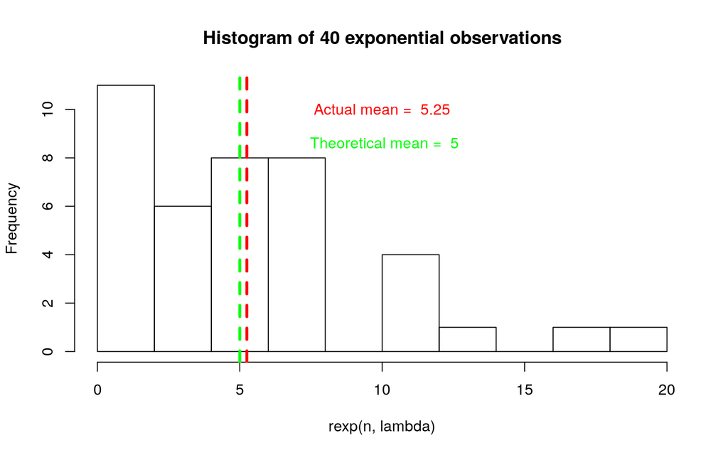

```r
hist(rexp(n,lambda), main=paste0("Histogram of ",n," exponential observations"))
abline(v=mean(obs), col="red", lwd=3, lty=2)
abline(v=mu, col="green", lwd=3, lty=2)
text(10,10, paste("Actual mean = ", round(mean(obs),2)), col="red")
text(10,9, paste(" ", "\n Theoretical mean = ",mu ), col="green")
```

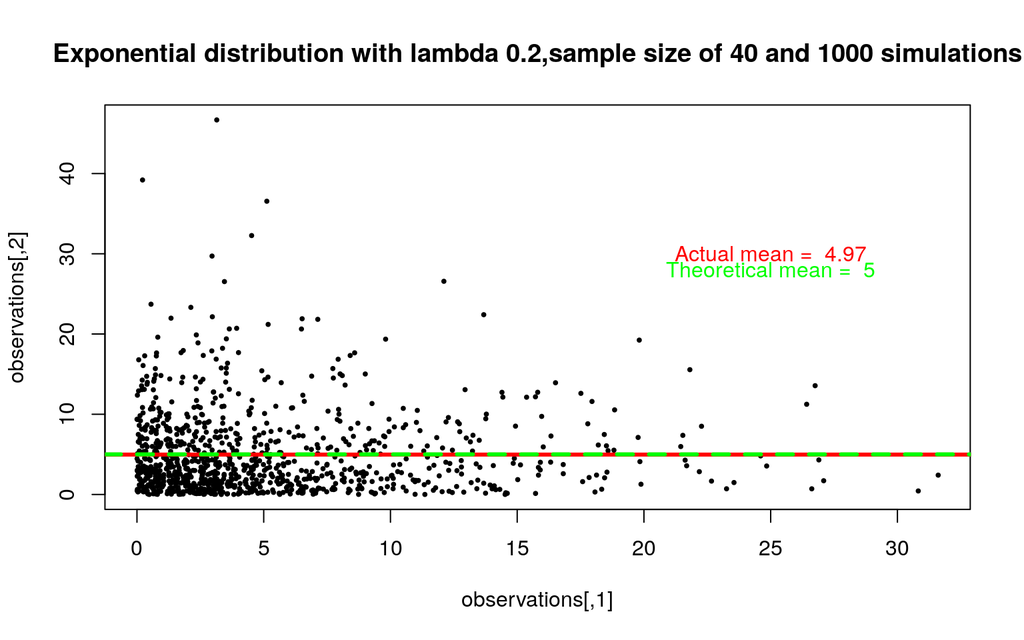

```r
library(ggplot2)
sample_size=40
lambda =.2
mu <- 1/lambda
s <- 1/lambda
num_sim <- 1000

observations <- matrix(rexp(num_sim * sample_size, rate = lambda), num_sim, sample_size)
means <- rowMeans(observations)

plot(observations, pch=20, cex=0.6, main=paste0("Exponential distribution with lambda ",lambda,",sample size of ",sample_size," and ",num_sim," simulations"))
abline(h=mean(observations), col="red", lwd=3, lty=1)
abline(h=mu, col="green", lwd=3, lty=2)
text(25, 30, paste("Actual mean = ", round(mean(observations),2)), col="red")
text(25, 28, paste("Theoretical mean = ",mu ), col="green")
```

```r
# theoretical mean  vs sample mean
print (paste("Population mean: ", mu, ", Sample mean: ", round(mean(observations) ,4) ) )
```

```
## [1] "Population mean:  5 , Sample mean:  4.9733"
```

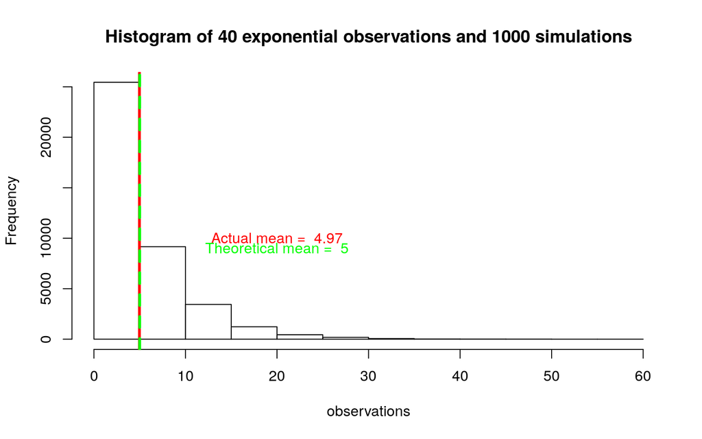

```r
hist(observations, main=paste0("Histogram of ",n," exponential observations and ",sim," simulations"))
abline(v=mean(observations), col="red", lwd=3, lty=1)
abline(v=mu, col="green", lwd=3, lty=2)
text(20,10000, paste("Actual mean = ", round(mean(observations),2)), col="red")
text(20,9000, paste("Theoretical mean = ",mu ), col="green")
```

2.- Show how variable the sample is (via variance) and compare it to the theoretical variance of the distribution.

```r
# theoretical standard deviation vs practical standard deviation
print (paste("Theoretical standard deviation: ", round( (1/lambda)/sqrt(n) ,4), ", Practical standard deviation", round(sd(means) ,4) ) )
```

```
## [1] "Theoretical standard deviation:  0.7906 , Practical standard deviation 0.8243"
```